# Problem 2: Stent Trial - Effect of Stenting on Stroke Risk

Introduction to R

# 1 Background

A randomized clinical trial evaluated the effect of **coronary stent placement** in stroke patients at risk for a further stroke event, relative to a control group receiving **standard treatment without a stent**. Patients were followed up at **30 days** and **365 days** after the index stroke. The trial was stopped prematurely due to safety concerns.

# 2 Task 1: Read in stent.txt

```r
# Load required libraries
library(tidyverse)
library(knitr)
library(kableExtra)
library(epitools)
library(scales)
library(gridExtra)
library(patchwork)

# Read data
stent_raw <- read.table(
  "Data/stent.txt",
  header           = TRUE,
  sep              = "",
  stringsAsFactors = FALSE
)

cat("Dimensions:", nrow(stent_raw), "rows x", ncol(stent_raw), "columns\n\n")
```

```
## Dimensions: 451 rows x 4 columns
```

```r
head(stent_raw, 5) |>
  kable(
    caption  = "First rows of the raw stent dataset.",
    booktabs = TRUE
  ) |>
  kable_styling(font_size = 10, position = "center")
```

First rows of the raw stent dataset.

| V1 | V2 | V3 | V4 |
| --- | --- | --- | --- |
| 1 | 2 | 1 | 1 |
| 2 | 2 | 1 | 1 |
| 3 | 2 | 1 | 1 |
| 4 | 2 | 1 | 1 |
| 5 | 2 | 1 | 1 |

# 3 Task 2: Define Informative Variable Names

```r
stent_raw <- stent_raw |>
  rename(
    patient_id      = V1,   # unique patient identifier
    treatment_group = V2,   # 1 = control, 2 = stent
    outcome_30d     = V3,   # stroke at 30 days (0 = no, 1 = yes)
    outcome_365d    = V4    # stroke at 365 days (0 = no, 1 = yes)
  )

cat("Updated variable names:\n")
```

```
## Updated variable names:
```

```r
names(stent_raw)
```

```
## [1] "patient_id"      "treatment_group" "outcome_30d"     "outcome_365d"
```

# 4 Task 3: Convert Grouping Variables to Factors

```r
stent <- stent_raw |>
  mutate(
    treatment_group = factor(
      treatment_group,
      levels = c(1, 2),
      labels = c("Control (no stent)", "Treatment (stent)")
    ),
    outcome_30d = factor(
      outcome_30d,
      levels = c(0, 1),
      labels = c("No Stroke", "Stroke")
    ),
    outcome_365d = factor(
      outcome_365d,
      levels = c(0, 1),
      labels = c("No Stroke", "Stroke")
    )
  )

str(stent)
```

```
## 'data.frame':    451 obs. of  4 variables:
##  $ patient_id     : int  1 2 3 4 5 6 7 8 9 10 ...
##  $ treatment_group: Factor w/ 2 levels "Control (no stent)",..: 2 2 2 2 2 2 2 2 2 2 ...
##  $ outcome_30d    : Factor w/ 2 levels "No Stroke","Stroke": 2 2 2 2 2 2 2 2 2 2 ...
##  $ outcome_365d   : Factor w/ 2 levels "No Stroke","Stroke": 2 2 2 2 2 2 2 2 2 2 ...
```

```r
cat("\nSample sizes per group:\n")
```

```
##
## Sample sizes per group:
```

```r
table(stent$treatment_group)
```

```
##
## Control (no stent)  Treatment (stent)
##                227                224
```

# 5 Task 4: Frequency Tables

## 5.1 Treatment vs Outcome at 30 Days

```r
tab_30d <- table(
  `Treatment Group` = stent$treatment_group,
  `30-Day Outcome`  = stent$outcome_30d
)

addmargins(tab_30d) |>
  kable(
    caption  = "Frequency table: treatment group vs. outcome at 30-day follow-up.",
    booktabs = TRUE
  ) |>
  kable_styling(font_size = 10, position = "center") |>
  add_header_above(c(" " = 1, "30-Day Stroke Outcome" = 2, " " = 1))
```

Frequency table: treatment group vs. outcome at 30-day follow-up.

|  | 30-Day Stroke Outcome No Stroke | 30-Day Stroke Outcome Stroke | Sum |
| --- | --- | --- | --- |
| Control (no stent) | 214 | 13 | 227 |
| Treatment (stent) | 191 | 33 | 224 |
| Sum | 405 | 46 | 451 |

```r
# Row proportions
round(prop.table(tab_30d, margin = 1) * 100, 2) |>
  addmargins() |>
  kable(
    caption  = "Row proportions (%) for 30-day outcome by treatment group.",
    booktabs = TRUE
  ) |>
  kable_styling(font_size = 10, position = "center")
```

Row proportions (%) for 30-day outcome by treatment group.

|  | No Stroke | Stroke | Sum |
| --- | --- | --- | --- |
| Control (no stent) | 94.27 | 5.73 | 100 |
| Treatment (stent) | 85.27 | 14.73 | 100 |
| Sum | 179.54 | 20.46 | 200 |

## 5.2 Treatment vs Outcome at 365 Days

```r
tab_365d <- table(
  `Treatment Group` = stent$treatment_group,
  `365-Day Outcome` = stent$outcome_365d
)

addmargins(tab_365d) |>
  kable(
    caption  = "Frequency table: treatment group vs. outcome at 365-day follow-up.",
    booktabs = TRUE
  ) |>
  kable_styling(font_size = 10, position = "center") |>
  add_header_above(c(" " = 1, "365-Day Stroke Outcome" = 2, " " = 1))
```

Frequency table: treatment group vs. outcome at 365-day follow-up.

|  | 365-Day Stroke Outcome No Stroke | 365-Day Stroke Outcome Stroke | Sum |
| --- | --- | --- | --- |
| Control (no stent) | 199 | 28 | 227 |
| Treatment (stent) | 179 | 45 | 224 |
| Sum | 378 | 73 | 451 |

```r
round(prop.table(tab_30d, margin = 1) * 100, 2) |>
  addmargins() |>
  kable(
    caption  = "Row proportions (%) for 365-day outcome by treatment group.",
    booktabs = TRUE
  ) |>
  kable_styling(font_size = 10, position = "center")
```

[output not shown]

# 6 Task 5: Plot - Proportion with Stroke at 30-Day Follow-Up

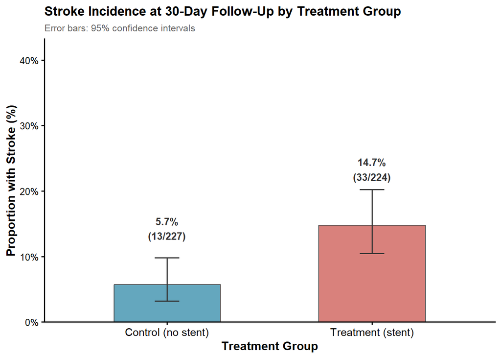

Proportion of patients who experienced a stroke at 30-day follow-up, by treatment group. Error bars represent 95% confidence intervals. Labels show the observed proportion and absolute count.

```r
# Compute proportions and 95% CI per treatment group
prop_30d <- stent |>
  group_by(treatment_group) |>
  summarise(
    n_stroke = sum(outcome_30d == "Stroke"),
    n_total  = n(),
    .groups  = "drop"
  ) |>
  mutate(
    prop     = n_stroke / n_total,
    ci_lower = mapply(function(x, n) prop.test(x, n)$conf.int[1], n_stroke, n_total),
    ci_upper = mapply(function(x, n) prop.test(x, n)$conf.int[2], n_stroke, n_total),
    label    = paste0(scales::percent(prop, accuracy = 0.1),
                      "\n(", n_stroke, "/", n_total, ")")
  )

colores <- c("Control (no stent)" = "#4E9BB5", "Treatment (stent)" = "#D4706A")

ggplot(prop_30d, aes(x = treatment_group, y = prop, fill = treatment_group)) +
  geom_col(width = 0.52, alpha = 0.88, colour = "grey30", linewidth = 0.4) +
  geom_errorbar(aes(ymin = ci_lower, ymax = ci_upper),
                width = 0.12, linewidth = 0.7, colour = "grey20") +
  geom_text(aes(label = label),
            vjust = -2, size = 3.6, fontface = "bold", colour = "grey20") +
  scale_fill_manual(values = colores) +
  scale_y_continuous(
    labels = scales::percent_format(accuracy = 1),
    limits = c(0, 0.40),
    expand = expansion(mult = c(0, 0.08))
  ) +
  labs(
    title    = "Stroke Incidence at 30-Day Follow-Up by Treatment Group",
    subtitle = "Error bars: 95% confidence intervals",
    x        = "Treatment Group",
    y        = "Proportion with Stroke (%)"
  ) +
  theme_classic(base_size = 12) +
  theme(
    plot.title      = element_text(face = "bold", size = 13),
    plot.subtitle   = element_text(size = 9.5, colour = "grey40"),
    legend.position = "none",
    axis.title      = element_text(face = "bold"),
    axis.text.x     = element_text(size = 11)
  )
```

# 7 Task 6: Odds Ratio for Stroke at 30 Days

```r
# 2x2 contingency table
tab_or <- matrix(
  c(
    sum(stent$treatment_group == "Control (no stent)"  & stent$outcome_30d == "No Stroke"),
    sum(stent$treatment_group == "Control (no stent)"  & stent$outcome_30d == "Stroke"),
    sum(stent$treatment_group == "Treatment (stent)"   & stent$outcome_30d == "No Stroke"),
    sum(stent$treatment_group == "Treatment (stent)"   & stent$outcome_30d == "Stroke")
  ),
  nrow = 2, byrow = TRUE,
  dimnames = list(
    Exposure = c("Control", "Stent"),
    Outcome  = c("No Stroke", "Stroke")
  )
)

cat("2 x 2 contingency table:\n")
```

```
## 2 x 2 contingency table:
```

```r
print(tab_or)
```

```
##          Outcome
## Exposure  No Stroke Stroke
##   Control       214     13
##   Stent         191     33
```

```r
# Calculate OR (Wald method)
or_result <- oddsratio(tab_or, method = "wald")

or_val <- or_result$measure["Stent", "estimate"]
ci_lo  <- or_result$measure["Stent", "lower"]
ci_hi  <- or_result$measure["Stent", "upper"]
p_chi  <- or_result$p.value["Stent", "chi.square"]

tibble(
  Comparison = "Stent vs. Control",
  OR         = round(or_val, 3),
  CI_lower   = round(ci_lo,  3),
  CI_upper   = round(ci_hi,  3),
  `p-value`  = format(p_chi, digits = 3)
) |>
  kable(
    caption   = "Odds ratio (OR) and 95% CI for stroke at 30-day follow-up in the stent group vs. control group (Wald method).",
    col.names = c("Comparison", "OR", "95% CI Lower", "95% CI Upper", "p-value"),
    booktabs  = TRUE
  ) |>
  kable_styling(font_size = 10, position = "center")
```

Odds ratio (OR) and 95% CI for stroke at 30-day follow-up in the stent group vs. control group (Wald method).

| Comparison | OR | 95% CI Lower | 95% CI Upper | p-value |
| --- | --- | --- | --- | --- |
| Stent vs. Control | 2.844 | 1.454 | 5.563 | 0.00158 |

# 8 Task 7: Interpretation

The odds ratio calculated above is **OR = 2.844** (95% CI: 1.454-5.563; p = 0.00158), comparing the stent group against the control group at 30-day follow-up.

## 8.1 Statistical Reasoning

An OR **greater than 1.0** indicates that patients who received the stent had **higher odds of experiencing a stroke at 30 days** compared to those who received standard care. The 95% confidence interval does not include 1.0, confirming statistical significance at the 5% level.

## 8.2 Clinical Reasoning

This finding is **fully consistent** with the decision to stop the trial prematurely:

1. **Direction of effect**: The OR > 1.0 means the stent was associated with *more strokes*, not fewer — a clear signal of potential harm rather than benefit.
2. **Magnitude**: An OR of 2.84 represents a clinically meaningful increase in short-term stroke risk that warrants serious attention.
3. **Safety monitoring**: Data Safety Monitoring Boards (DSMBs) apply pre-specified stopping rules based on interim analyses. An OR of this magnitude at 30 days would very likely trigger such a boundary.
4. **Ethical obligation**: When interim analysis provides compelling evidence of harm, continuation of the trial would expose patients to unnecessary risk, violating the principle of equipoise.

## 8.3 Conclusion

The OR of 2.844 (95% CI: 1.454-5.563) is fully consistent with the early termination of this trial on safety grounds. The stent, rather than reducing the risk of recurrent stroke at 30 days, was associated with substantially higher odds of this outcome compared to standard care.